# Analyze of storm events on United States

Massimiliano Pinato

29/9/2016

# Synopsis

We analyze storm data to find most dangerous events and events with biggest economics conseguences, using data from NOAA and calculate with R Studio.

# Data Processing and Discovery

```r
library(plyr) #I need for revaluate
library(dplyr) # I use that for manipulate data
library(data.table) #I use that for faster read csv file
library(lubridate) #I use that for manipulate date/time
```

```r
library(ggplot2) #I use that for plot
library(knitr) #I use that for knitr function like 'kable' for example
library(stringdist) #I use this for calculate distance of events type string
library(stringr) #I use this for abbreviation
library(cowplot) #I use this in order to plot two different chart in the same row
```

Now I declare functions that I use more times. In this research I need only a function that make me simply to simulate different cut of hierarchical clusterization of event type names, in order to choose the optimal cutoff value.

```r
#Description: Get a data.frame based on a specific high of a
#             hierachical clusterization.
#Use: I use that in order to simulate differents cut and choose
#     the optimal cutoff value.
fn.getEventClusterOffset <- function(events,lstHC,offset){

  lst_hc <- as.data.frame(cutree(lstHC,h=offset))
  lst_hc$EVTYPE <- events
  colnames(lst_hc) <- c("Cluster","EVTYPE")
  lst_hc <- lst_hc %>% arrange(Cluster)
  return(lst_hc)
}
```

Now, I have to read the data downloaded by the link on (STORM DATA)[https://d396qusza40orc.cloudfront.net/repdata%2Fdata%2FStormData.csv.bz2,Link].

In order to reproduce the present research you have to download the file, unzip, and save on the current folder with the name ´repdata-data-StormData.csv`,

First elaboration is read the file. I use `fread` for performance reason.

```r
dfStorm <- fread("repdata-data-StormData.csv") #read file
```

```
##
Read 10.3% of 967216 rows
Read 37.2% of 967216 rows
Read 54.8% of 967216 rows
Read 75.5% of 967216 rows
Read 82.7% of 967216 rows
Read 902297 rows and 37 (of 37) columns from 0.523 GB file in 00:00:07
```

According to the data dictionary, we have to consider data since 1996. I first format data field `BGN_DATE` as date type in r-lang, and then I apply a filter cross all my analysis.

```r
#Date Format and Filter
dfStorm.flt <- dfStorm %>%
  mutate( BGN_DATE = as.Date(as.character(BGN_DATE),"%m/%d/%Y %H:%M:%S") ) %>%
  filter(year(BGN_DATE) >= 1996)
```

## Clusterize Event types

During data discovery we can see that most event type names refer to the same real event type. The list is too big to be simplified with a regular expression. I choose to use hierarchical aggregation.

```r
lstEv <- unique(dfStorm.flt$EVTYPE)
dstEv <- stringdistmatrix(lstEv,lstEv,method="jw")
rownames(dstEv) <- lstEv
lstEv_hc <- hclust(as.dist(dstEv))
```

Now that I have my hiearchical clusterization, I want to find the right cutoff value to have cluster with similar events. I’ve simulated cutoff value between 0.10 and 0.40 (by an interval off 0.05) observing the cluster items and searching error of clusterization. To simplify my work I’ve used the following instruction.

```r
lstEv_hc.c10 <- fn.getEventClusterOffset(lstEv,lstEv_hc,0.10)
lstEv_hc.c15 <- fn.getEventClusterOffset(lstEv,lstEv_hc,0.15)
lstEv_hc.c20 <- fn.getEventClusterOffset(lstEv,lstEv_hc,0.20)
lstEv_hc.c25 <- fn.getEventClusterOffset(lstEv,lstEv_hc,0.25)
lstEv_hc.c30 <- fn.getEventClusterOffset(lstEv,lstEv_hc,0.30)
lstEv_hc.c35 <- fn.getEventClusterOffset(lstEv,lstEv_hc,0.35)
lstEv_hc.c40 <- fn.getEventClusterOffset(lstEv,lstEv_hc,0.40)
```

For every clusterization, I’ve searched for error (starting from the bigger cutoff value).

0.40 fails on cluster 2.

```r
kable(lstEv_hc.c40 %>% filter(Cluster == 2))
```

| Cluster | EVTYPE |
| --- | --- |
| 2 | TORNADO |
| 2 | TORNADO DEBRIS |
| 2 | TSUNAMI |

0.35 fails on cluster 36.

```r
kable(lstEv_hc.c35 %>% filter(Cluster == 36))
```

| Cluster | EVTYPE |
| --- | --- |
| 36 | Wind |
| 36 | Wintry Mix |
| 36 | Wintry mix |

0.30 fails on cluster 168.

```r
kable(lstEv_hc.c30 %>% filter(Cluster == 168))
```

| Cluster | EVTYPE |
| --- | --- |
| 168 | DRY WEATHER |
| 168 | HOT WEATHER |
| 168 | WARM WEATHER |
| 168 | COLD WEATHER |

The value of *0.25* seems to be an optimal value of cutoff. So, I can prepare a final dataframe with the indication of the cluster. In particular, I add a new column in the original data.frame, `EVTYPE.CLUSTER` with the first event type name of the cluster.

```r
lstEv_hc.optimal <- lstEv_hc.c25 %>% #choose the optimal clustere
  group_by(Cluster) %>% #group by cluster
  mutate(EVTYPE.CLUSTER = min(EVTYPE)) %>% #prepare the cluster name
  ungroup() #return with the entire data.frame
#Merge with the original data.frame in order to associate the EVTYPE.CLUSTER
#of the corresponding EVTYPE
dfStorm.clustered <- merge(dfStorm.flt,lstEv_hc.optimal,
    by.x = "EVTYPE",by.y = "EVTYPE",all.x = T,all.y = F)
```

Now we have a data.frame clusterized that we can use cross all our analysis.

## Prepare dangerous data.frame for most dangerous events

In order to analyze dangerous, I cluster, fatalities and injurious. So, first I simplify my data.frame and summarize for fatalities and injurious.

```r
dfStorm.dang <- dfStorm.clustered %>%
  select(EVTYPE.CLUSTER,FATALITIES,INJURIES) %>%
  group_by(EVTYPE.CLUSTER) %>%
  dplyr::summarise(
    FAT.TOT = sum(as.numeric(as.character(FATALITIES))),
    INJ.TOT = sum(as.numeric(as.character(INJURIES)))
  )
```

Now we can prepare the top 5 events for both the measures. I prepare two separated data.frame (because I want to have two differents perspective).

```r
dfStorm.dang.top5Fatal <- dfStorm.dang %>%
  top_n(5,FAT.TOT) %>% #select top 5
  arrange(desc(FAT.TOT)) %>% #order by fatalities
  select(EVTYPE.CLUSTER,FAT.TOT) %>% #simplify dataset
  mutate(EVTYPE.ABBR = abbreviate(EVTYPE.CLUSTER,minlength=6)) #abbreviate description

dfStorm.dang.top5Injur <- dfStorm.dang %>%
  top_n(5,INJ.TOT) %>% #select top5
  arrange(desc(INJ.TOT)) %>% #order by fatalities
  select(EVTYPE.CLUSTER,INJ.TOT) %>% #simplify dataset
  mutate(EVTYPE.ABBR = abbreviate(EVTYPE.CLUSTER,minlength=6)) #abbreviate description
```

Finally I prepare two simple bar plot.

```r
g.fatal <- ggplot(dfStorm.dang.top5Fatal, aes(x = EVTYPE.ABBR,y = FAT.TOT)) +
  geom_bar(stat = "identity") +
  ggtitle("Most dangerous - Fatalities" ) +
  labs(x="Events (clustered)",y="Fatalities")
g.injuries <- ggplot(dfStorm.dang.top5Injur, aes(x = EVTYPE.ABBR,y = INJ.TOT)) +
  geom_bar(stat = "identity") +
  ggtitle("Most dangerous - Injuries" ) +
  labs(x="Events (clustered)",y="Injuries")
```

## Prepare economics data.frame for gratest economics conseguences events

In order to work with economics data I’ve first to format the exponetial of damage value, to calculate the damage cash. According to data dictionary, exponential are “K” (x1000), “M” (x10^6) and “B” (x10^9). Data have others value not recognized. I want to verify the impact of the others value.

```r
#Valuate PROPDMGEXP. I need to use explicit library prefix because n() is in conflicts
#between plyr and dplyr (and I need both the library)
dfPExp <- dfStorm.flt %>%
  group_by(PROPDMGEXP) %>%
  dplyr::summarise(    CNT = n(),    VAL = sum(PROPDMG)  )
kable(dfPExp)
```

| PROPDMGEXP | CNT | VAL |
| --- | --- | --- |
| K | 369938 | 7539105.38 |
|  | 276185 | 0.00 |
| M | 7374 | 101878.51 |
| B | 32 | 257.35 |
| 0 | 1 | 0.00 |

```r
#Valuate CROPDMGEXP
dfCExp <- dfStorm.flt %>%
  group_by(CROPDMGEXP) %>%
  dplyr::summarise(CNT = n(),VAL = sum(CROPDMG))
kable(dfCExp)
```

| CROPDMGEXP | CNT | VAL |
| --- | --- | --- |
| K | 278686 | 1170778.73 |
|  | 373069 | 0.00 |
| M | 1771 | 31071.95 |
| B | 4 | 2.51 |

For property damage (the table `PROPDMGEXP`) we 1 result with “0” exponential and about 50% of measurement with empty. All this measures have value empty, so they can be ignored, as well as for crop damage (table `CROPDMGEXP`).

So, I decide to filter dataframe excluding the measure that have exponential not in K/M/B.

```r
dfStorm.economics <- dfStorm.clustered %>% select(EVTYPE.CLUSTER,CROPDMG,CROPDMGEXP,PROPDMG,PROPDMGEXP)
dfStorm.fltValidCash <- dfStorm.economics %>%
  filter( CROPDMGEXP %in% c("K","M","B") & PROPDMGEXP %in% c("K","M","B") )
```

Now I have to calculate cash for property, crop, and total cash value (as sum of property and cash), applying the correct exponential. In order to calculate the exponential I use the function `revalue` of plyr library that apply the mapping from a vector.

```r
lstMapping <- c("K" = 10^3,"M" = 10^6,"B" = 10^9)
#Calculate Cash Exponential
dfStorm.wCashExp <- dfStorm.fltValidCash %>%
  mutate(
    CEXP = revalue(CROPDMGEXP ,lstMapping),
    PEXP = revalue(PROPDMGEXP ,lstMapping)
  )
#Calculate correct cash and overall cash
dfStorm.wCash <- dfStorm.wCashExp %>%
  mutate(
    CROP.CASH = as.numeric(CROPDMG) * as.numeric(CEXP),
    PROP.CASH = as.numeric(PROPDMG) * as.numeric(PEXP)
  )
#Finally, I summarise calculating overall cash and grouping
#by event type cluster.
dfStorm.wCash <- dfStorm.wCash %>%
  mutate( OVER.CASH = CROP.CASH + PROP.CASH) %>%
  group_by(EVTYPE.CLUSTER) %>%
  dplyr::summarise(
    CROP.CASH.TOT = sum(CROP.CASH),
    PROP.CASH.TOT = sum(PROP.CASH),
    OVER.CASH.TOT = sum(OVER.CASH)
  )
```

Now that I have my dataframe groupped and summarized, I can calculate top 5 of the three measures.

```r
dfStorm.eco.top5Crop <- dfStorm.wCash %>%
  top_n(5,CROP.CASH.TOT) %>%
  arrange(desc(CROP.CASH.TOT)) %>%
  select(EVTYPE.CLUSTER,CROP.CASH.TOT) %>%
  mutate(EVTYPE.ABBR = abbreviate(EVTYPE.CLUSTER,minlength=6))

dfStorm.eco.top5Prop <- dfStorm.wCash %>%
  top_n(5,PROP.CASH.TOT) %>%
  arrange(desc(PROP.CASH.TOT)) %>%
  select(EVTYPE.CLUSTER,PROP.CASH.TOT) %>%
  mutate(EVTYPE.ABBR = abbreviate(EVTYPE.CLUSTER,minlength=6))

dfStorm.eco.top5Overall <- dfStorm.wCash %>%
  top_n(5,OVER.CASH.TOT) %>%
  arrange(desc(OVER.CASH.TOT)) %>%
  select(EVTYPE.CLUSTER,OVER.CASH.TOT) %>%
  mutate(EVTYPE.ABBR = abbreviate(EVTYPE.CLUSTER,minlength=6))
```

And now I prepare the relative chart.

```r
g.ecoCrop <- ggplot(dfStorm.eco.top5Crop, aes(x = EVTYPE.ABBR,y = CROP.CASH.TOT)) +
  geom_bar(stat = "identity") +
  ggtitle("Most expansive - Crop Damage" ) +
  labs(x="Events (clustered)",y="Crop Damage")

g.ecoProp <- ggplot(dfStorm.eco.top5Prop, aes(x = EVTYPE.ABBR,y = PROP.CASH.TOT)) +
  geom_bar(stat = "identity") +
  ggtitle("Most expansive - Property Damage" ) +
  labs(x="Events (clustered)",y="Property Damage")

g.ecoOver <- ggplot(dfStorm.eco.top5Overall, aes(x = EVTYPE.ABBR,y = OVER.CASH.TOT)) +
  geom_bar(stat = "identity") +
  ggtitle("Most expansive - Overall Damage" ) +
  labs(x="Events (clustered)",y="Overall Damage")
```

# Results

I have analyzed storm data of the last 20 years on Unites States, in order to valuate the most dangerous events and the events with the biggest economics conseguences. In the following paragraphes we show which events are most relevants.

## Most Dangerous Events

For the dangerous I have analyzed separately fatalities and injurious. We now can see the results.

```r
kable(dfStorm.dang.top5Fatal)
```

| EVTYPE.CLUSTER | FAT.TOT | EVTYPE.ABBR |
| --- | --- | --- |
| EXCESSIVE HEAT | 1797 | EXCESH |
| TORNADO | 1511 | TORNAD |
| FLASH FLOOD | 887 | FLASHF |
| LIGHTNING | 651 | LIGHTN |
| RIP CURRENT | 542 | RIPCUR |

```r
kable(dfStorm.dang.top5Injur)
```

| EVTYPE.CLUSTER | INJ.TOT | EVTYPE.ABBR |
| --- | --- | --- |
| TORNADO | 20667 | TORNAD |
| FLASH FLOOD/FLOOD | 6758 | FLASHF |
| EXCESSIVE HEAT | 6391 | EXCESH |
| LIGHTNING | 4141 | LIGHTN |
| TSTM WIND | 3633 | TSTMWI |

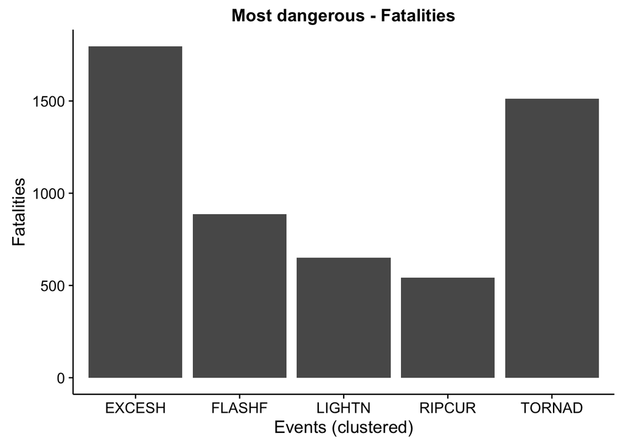

```r
g.fatal
```

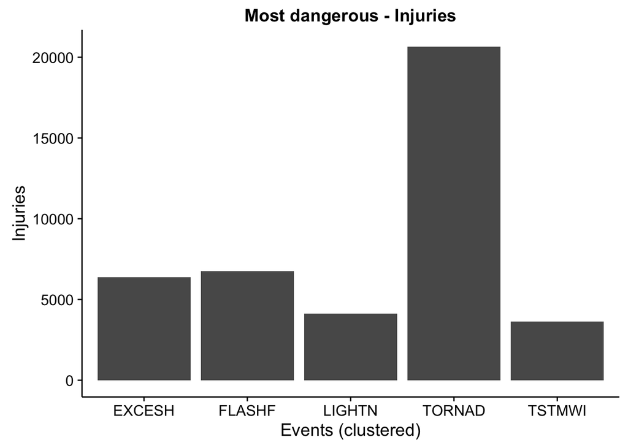

```r
g.injuries
```

In general, Tornado and Excessive Heat are the events most dangerous.

## Greatest Economics Conseguences

For economics conseguences, I have analyzed separately property and crop damage, and I have calculate overall damage with sum of both the measures.

So, here the results.

```r
kable(dfStorm.eco.top5Prop)
```

| EVTYPE.CLUSTER | PROP.CASH.TOT | EVTYPE.ABBR |
| --- | --- | --- |
| FLASH FLOOD/FLOOD | 132485992500 | FLASHFLOOD/ |
| HURRICANE | 36456153000 | HURRIC |
| TORNADO | 16030944840 | TORNAD |
| HAIL | 7602176090 | HAIL |
| FLASH FLOOD | 7094277830 | FLASH FLOOD |

```r
kable(dfStorm.eco.top5Crop)
```

| EVTYPE.CLUSTER | CROP.CASH.TOT | EVTYPE.ABBR |
| --- | --- | --- |
| HURRICANE | 5296282800 | HURRIC |
| FLASH FLOOD/FLOOD | 4792831400 | FLASHFLOOD/ |
| HAIL | 1729112500 | HAIL |
| DROUGHT | 1634696000 | DROUGH |
| FLASH FLOOD | 1307821700 | FLASH FLOOD |

```r
kable(dfStorm.eco.top5Overall)
```

| EVTYPE.CLUSTER | OVER.CASH.TOT | EVTYPE.ABBR |
| --- | --- | --- |
| FLASH FLOOD/FLOOD | 137278823900 | FLASHFLOOD/ |
| HURRICANE | 41752435800 | HURRIC |
| TORNADO | 16308770350 | TORNAD |
| HAIL | 9331288590 | HAIL |
| FLASH FLOOD | 8402099530 | FLASH FLOOD |

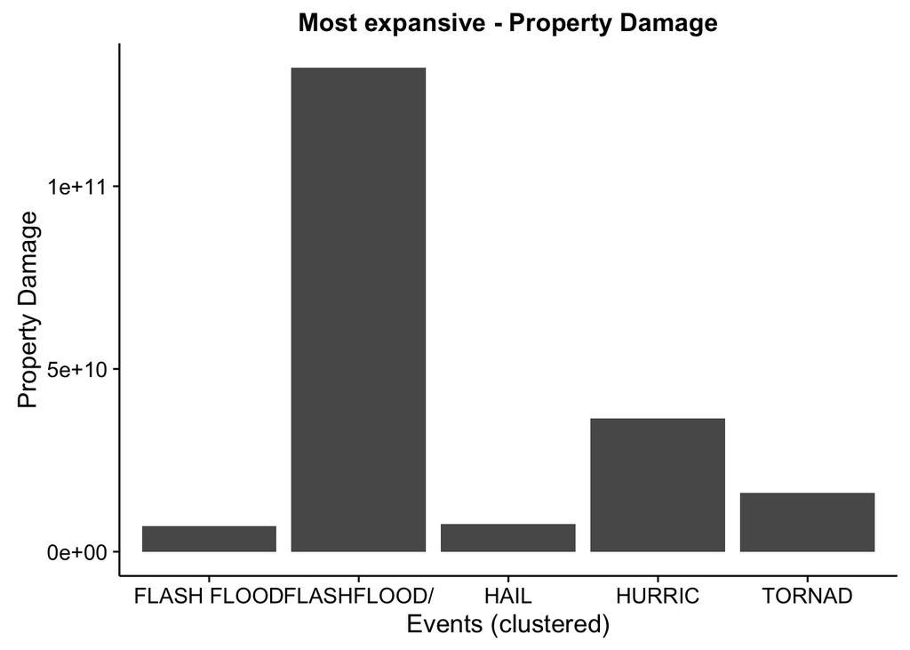

```r
g.ecoProp
```

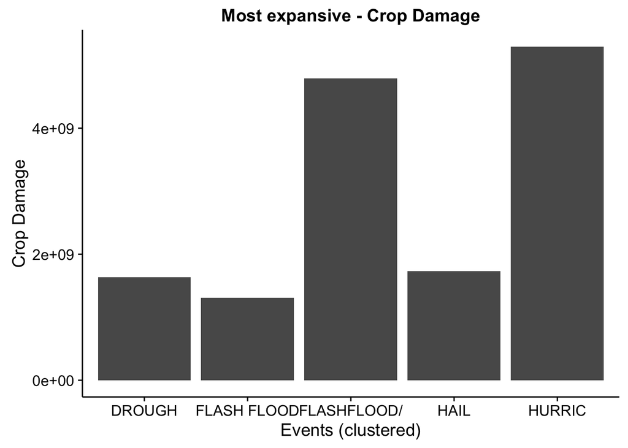

```r
g.ecoCrop
```

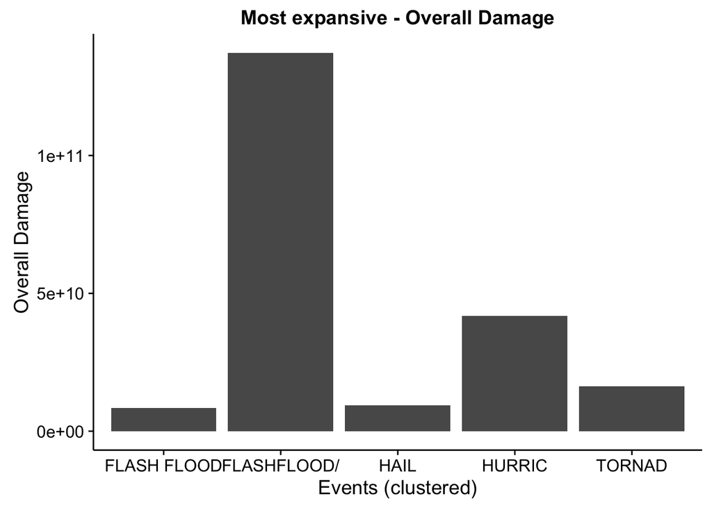

```r
g.ecoOver
```

In general, flash flood have biggest economics conseguences in the last 20 years.